# Circular Dataset Structures

James Foster

2025-10-29

## Details

> **DESCRIPTION**

> Example of a circular GLMM.

> **REFERENCES**

> Sayin S, Couzin-Fuchs E, Petelski I, Günzel Y, Salahshour M, Lee CY, Graving JM, Li L, Deussen O, Sword GA, et al. (2025) The behavioral mechanisms governing collective motion in swarming locusts. Science. 387(6737):995–791

> Gabry J, Češnovar R, Johnson A (2022). cmdstanr: R Interface to ‘CmdStan’. https://mc-stan.org/cmdstanr/

> Bürkner, P.-C. (2018). Advanced Bayesian Multilevel Modeling with the R Package brms. The R Journal 10, 395–411.

> Carpenter, B., Gelman, A., Hoffman, M. D., Lee, D., Goodrich, B., Betancourt, M., Brubaker, M., Guo, J., Li, P. and Riddell, A. (2017). Stan: A Probabilistic Programming Language. Journal of Statistical Software 76 doi: 10.18637/jss.v076.i01

## Set up workspace

Set up some colours for plotting.

```r
col_kappa = '#1E78B5'#colour for kappa parameter
col_rho = '#F08024' #colour for mean vector length
col_sd = '#E74A29' #colour for SD and mean angle
col_sd2 = '#E57461' #colour for other SD heuristics
col_pdf = adjustcolor(col = '#21A885', # colour for probability density
                      alpha.f = 0.7)
col_obs = '#3E1F51' #colour for control observations
col_treat = '#006400' # colour for treatment observations
```

# Load packages

```r
#package for circular data
require(circular)
#package for Bayesian modelling in Stan
require(cmdstanr)
#package for building Stan models
require(brms)
```

# Set up functions

These functions that wrap angular data into a single circle and generate & plot new samples of circular data.

```r
#convert angles to signed angles in (-180, 180)
Mod360.180 = function(x)
{#use atan2 to convert any angle to the range (-180,180)
  deg(
    atan2(y = sin(rad(x)),
          x = cos(rad(x))
    )
  )
}

#the radian equivalent
mod_circular = function(x)
{
  atan2(y = sin(x),
        x = cos(x))
}

#the unwrapped (no discontinuities)
unwrap_circular = function(x)
{
  mux = mean.circular(x = circular(x = x, template = 'none'))
  centx = atan2(y = sin(x - mux),
                x = cos(x  - mux))
  unwrx = centx + mux
}

#degree version
unwrap_circular_deg = function(x)
{
  mux = mean.circular(x = circular(x = x, template = 'none'))
  centx = atan2(y = sin(x - mux),
                x = cos(x  - mux))
  unwrx = centx + mux
  return(deg(unwrx))
}



DescriptCplot = function(k,
                         m = 0,#in degrees
                         ndata = 20,
                         lw = 3,
                         pcol = col_obs,
                         mvcol = col_rho,
                         denscol = col_pdf,
                         bins = 360/5-1,
                         stack = TRUE,
                         sep = 0.05,
                         shrink = 1.25,
                         refline = NA,
                         save_sample = FALSE,
                         seed = 20250815,
                         titleline = -1,
                         ...#passed to points.circular
)
{
  #convert mu to circular class
  cm = circular(x = m,
                units = 'degrees',
                rotation = 'clock',
                zero = pi/2)
  #kappa = 0 v. random, make repeatable
  set.seed(seed)
  #generate dataset
  cd = rvonmises(mu = cm,
                 kappa = k,
                 n = ndata)
  #Generate a vector of angles
  ra = seq(from = -pi, to = pi, by = 0.01)
  ra = circular(ra,
                units = 'radians',
                rotation = 'counter',
                zero = 0)
  #plot dataset
  plot.circular(x = circular(NA,
                             units = 'degrees',
                             rotation = 'clock',
                             zero = pi/2),
                stack = stack,
                bins = bins,
                shrink = shrink,
                sep = sep,
                col = pcol,
                axes = FALSE
  )
  #add reference line
  if(!is.na(refline))
  {
    arrows.circular(x = circular(refline,
                                 units = 'degrees',
                                 rotation = 'clock',
                                 zero = pi/2),
                    col = 'gray',
                    length = 0,
                    lend = 'butt',
                    lwd = lw)
  }
  #add probability density
  if(!is.na(denscol))
  {
  lines.circular(x = ra,
                 y = dvonmises(x = ra,
                               mu = cm,
                               kappa = k)/shrink,
                 col = denscol,
                 lwd = lw)
  }
  points.circular(cd,
                  stack = stack,
                  bins = bins,
                  shrink = shrink,
                  sep = sep,
                  col = pcol,
                  ...
  )
  #add the mean vector
  if(k>0)
  {
    arrows.circular(x = cm,
                    y = A1(k),
                    col = mvcol,
                    lwd = lw,
                    length = 0.1/shrink#,shrink = 1/shrink
    )
  }else
  {
    points(x = 0,
           y = 0,
           col = mvcol,
           pch = 19,
           lwd = lw)
  }

  #add a title
  mtext(text = paste0('κ = ', k),
        side = 1,
        line = titleline)
  if(save_sample)
  {return(cd)}
}

PCfun = function(angles,
                 col = 'darkblue',
                 shrink = 1.5,
                 title = '',
                 plot_rho = TRUE,
                 side = 1,
                 ...)
{
  ca = circular(x = angles,
                units = 'degrees',
                rotation = 'clock')
  plot.circular(x = ca,
                col = col,
                stack = TRUE,
                bins = 355/5,
                units = 'degrees',
                rotation = 'clock',
                zero = pi/2,
                shrink = shrink,
                ...)
  mtext(text = title,
        side = side,
        line = -2)
  lines(x = c(0,0),
        y = c(-1,1),
        col = 'gray')
  if(plot_rho)
  {
    arrows.circular(x = mean.circular(ca),
                    y = rho.circular(ca),
                    zero = pi/2,
                    rotation = 'clock',
                    col = col,
                    length =0.1)
  }
}
```

These functions extract and plot model predictions. Vertical histograms and circular density plots are used to show posterior density of model estimates. The Rhat unwrapping functions transform estimates to wrapped, centred circular distributions before calculating Rhat (chains may otherwise appear to diverge by $2\pi$). A custom log likelihood function for unwrapped models is needed for LOO-CV.

```r
## Modelling functions ---------------------------------------------------


#histograms on a vertical axis
#any data, but plotted as a histogram on a vertical rather than horizontal axis
VertHist = function(data, # numerical data vector
                    breaks = 1e2,
                    ylab = 'data',
                    xlab = 'density',
                    ylim = NULL,
                    main = '',
                    col = 'gray',
                    border = NA,
                    axes = TRUE,
                    ...)
{
  hst = hist(x = data, # calculate the histogram but don't plot it
             breaks = breaks, # user defined breaks
             plot = FALSE)
  with(hst,
       {
         plot(x = NULL, #open an empty plot
              xlim = c(0, max(density)),
              ylim = if(is.null(ylim)){range(mids)}else{ylim},
              xlab = xlab,
              ylab = ylab,
              main = main,
              axes = axes)
         #plot each bar
         for(i in 1:length(mids))
         {
           rect(xleft = 0,
                xright = density[i],
                ybottom = breaks[i],
                ytop = breaks[i + 1],
                col = col,
                border = border,
                ...
           )
         }
       }
  )
}


#add contours
Draws2Cont = function(draws,
                      palette = 'Heat 2',
                      nlevels = 20,
                      x_string = 'sin(Intercept)*A1(softplus(Intercept_kappa))',
                      y_string = 'cos(Intercept)*A1(softplus(Intercept_kappa))',
                      alpha = 200/255,
                      ngrid = 25, # defaults to a 25x25 grid
                      cropc = FALSE, #crop region outside circle
                      denstype = 'relative' # 'normalised' or 'relative' (normalised fails to plot low densities)
)
{
  kdc = with(draws,
             {
               MASS::kde2d(x = eval(str2lang(x_string)),
                           y = eval(str2lang(y_string)),
                           n = ngrid)
             }
  )
  if(cropc)
  {
    xy = with(kdc, expand.grid(x = x,y= y))#find coordinates of z variable
    idc = with(xy, x^2+y^2 < 1.0)
    #crop edge of circle
    kdc = within(kdc,
                 {z[!idc] = 0})
  }
  with(kdc,
       {
         .filled.contour(x = x,
                         y = y,
                         z = z,
                         levels = (1:nlevels)*
                           switch(EXPR = denstype,
                                  relative = max(z/nlevels),
                                  normalised = sum(z/nlevels),#warning, fails to plot low densities
                                  max(z/nlevels)
                           ),
                         col = hcl.colors(n = nlevels,
                                          palette = palette,
                                          rev = TRUE,
                                          alpha = alpha)
         )
       }
  )
}


#invert the softplus link
#https://en.wikipedia.org/wiki/Softplus
#we are using this as our _inverse_ link function for kappa,
#maps almost 1:1 but keeps values >0 for low estimates
softplus = function(x)
{
  log(exp(x)+1)
}
#this would return our kappa estimates back to the original scale
inv_softplus = function(x)
{
  log(exp(x)-1)
}


#calculate rhat for circular variables with extreme ranges
Rhat_unwrap = function(x){rhat(unwrap_circular(x))}
UnwrapRhats = function(uwmod,
                       variable = '^b_imu',
                       regex = TRUE,
                       digits = 5,
                       ...)
{
  rh =
    apply(X = as_draws_df(uwmod,
                          variable = variable,
                          regex = regex,
                          ...),
          MARGIN = 2,
          FUN = Rhat_unwrap)
  nrh = names(rh)
  rh = rh[!( nrh %in% c(".chain", ".iteration", ".draw") )]
  return( round(rh,digits = digits) )
}

#copy of log_lik_von_mises, with helper functions included & removal of circular formatting
log_lik_unwrap_von_mises <- function(i, prep) {
  #remove circular formatting?
  prep$data$Y = as.numeric(prep$data$Y)

  args <- list(
    mu = get_dpar(prep, "mu", i),
    kappa = get_dpar(prep, "kappa", i = i)
  )

  # ----------- log_lik helper-functions -----------
  # compute (possibly censored) log_lik values
  # @param dist name of a distribution for which the functions
  #   d<dist> (pdf) and p<dist> (cdf) are available
  # @param args additional arguments passed to pdf and cdf
  # @param prep a brmsprep object
  # @return vector of log_lik values
  log_lik_censor <- function(dist, args, i, prep) {
    pdf <- get(paste0("d", dist), mode = "function")
    cdf <- get(paste0("p", dist), mode = "function")
    y <- prep$data$Y[i]
    cens <- prep$data$cens[i]
    if (is.null(cens) || cens == 0) {
      x <- do_call(pdf, c(y, args, log = TRUE))
    } else if (cens == 1) {
      x <- do_call(cdf, c(y, args, lower.tail = FALSE, log.p = TRUE))
    } else if (cens == -1) {
      x <- do_call(cdf, c(y, args, log.p = TRUE))
    } else if (cens == 2) {
      rcens <- prep$data$rcens[i]
      x <- log(do_call(cdf, c(rcens, args)) - do_call(cdf, c(y, args)))
    }
    x
  }

  # adjust log_lik in truncated models
  # @param x vector of log_lik values
  # @param cdf a cumulative distribution function
  # @param args arguments passed to cdf
  # @param i observation number
  # @param prep a brmsprep object
  # @return vector of log_lik values
  log_lik_truncate <- function(x, cdf, args, i, prep) {
    lb <- prep$data[["lb"]][i]
    ub <- prep$data[["ub"]][i]
    if (is.null(lb) && is.null(ub)) {
      return(x)
    }
    if (!is.null(lb)) {
      log_cdf_lb <- do_call(cdf, c(lb, args, log.p = TRUE))
    } else {
      log_cdf_lb <- rep(-Inf, length(x))
    }
    if (!is.null(ub)) {
      log_cdf_ub <- do_call(cdf, c(ub, args, log.p = TRUE))
    } else {
      log_cdf_ub <- rep(0, length(x))
    }
    x - log_diff_exp(log_cdf_ub, log_cdf_lb)
  }

  # weight log_lik values according to defined weights
  # @param x vector of log_lik values
  # @param i observation number
  # @param prep a brmsprep object
  # @return vector of log_lik values
  log_lik_weight <- function(x, i, prep) {
    weight <- prep$data$weights[i]
    if (!is.null(weight)) {
      x <- x * weight
    }
    x
  }


  out <- log_lik_censor(
    dist = "von_mises", args = args, i = i, prep = prep
  )
  out <- log_lik_truncate(
    out, cdf = pvon_mises, args = args, i = i, prep = prep
  )
  log_lik_weight(out, i = i, prep = prep)
}
```

# Dataset with individual heading changes

Generate a dataset for a hypothetical experiment, in which a treatment causes individuals to change their headings.

## Set up population level parameters

The dataset includes repeated measures across individuals, with a large number of observations for each treatment. The treatment causes an average change in heading of only 30°. Individual directional biases are somewhat correlated ($\kappa=4.0$), the average individual is quite consistent across trials ($\kappa=3.0$) and individuals vary in consistency ($\sigma_\kappa=0.7$).

```r
# moderate sample of individuals
nindiv = 10
# large sample size per individual
ndata = 20

#moderate change in heading (30°) with change in treatment
delta_mu = circular(x = 30,
                    units = 'degrees',
                    rotation = 'clock',
                    zero = pi/2)
#individual differences with kappa = 4 (both treatments)
kappa_mu_treat = 4.0
#average individual quite consistent
kappa_treat_mean = 3.0
#large variance in individual consistency
kappa_treat_sd = 0.7
```

## Simulate individual level parameters

Here, each individual is assigned a unique von~Mises distribution, parametrised by mean angle $\mu$ and concentration $\kappa$. The treatment changes the population mean direction by $\delta_\mu$.

```r
# circular zero
c0 = circular(x = 0,
              units = 'degrees',
              rotation = 'clock',
              zero = pi/2)

set.seed(20251029)#Script started
#individual consistency
kappa_id_treat = rnorm(n = nindiv,
                    mean = kappa_treat_mean,
                    sd = kappa_treat_sd)
#rectified (kappa must be larger than 0)
kappa_id_treat[kappa_id_treat<0] = 0

# list of circular datasets
# set.seed(0120810506)#ISBN Batschelet, 1981
#generate individual headings for control
dt_treat = rvonmises(n = nindiv,
                  mu = c0,
                  kappa = kappa_mu_treat)
#generate individual headings after turn (delta mu)
dt_delta = rvonmises(n = nindiv,
                     mu = c0+delta_mu,
                     kappa = kappa_mu_treat)
```

## Generate dataset of trials per individual and treatment

Now, those individual parameters can be used to generate data for each individual and treatment. To avoid excessive correlation, different random number seeds are used each time.

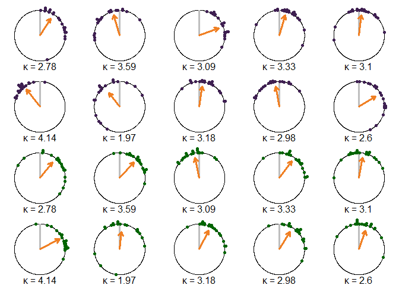

```r
par(pty = 's')
par(mar = c(0,0,0,0))
par(mfrow = c(2*2,ceiling(nindiv/2)))
#control treatment
dt_id_treat = mapply(m = dt_treat,
                  k = round(kappa_id_treat,2),
                  FUN = DescriptCplot,
                  save_sample = TRUE,
                  ndata = ndata,
                  refline = 0,
                  denscol = NA,
                  seed = 0120810506 + 1:nindiv, #ISBN Batschelet, 1981
                  SIMPLIFY = FALSE)
#experiment treatment
dt_id_delta = mapply(m = dt_delta,
                     k = round(kappa_id_treat,2),
                     FUN = DescriptCplot,
                     save_sample = TRUE,
                     pcol = 'darkgreen',
                     ndata = ndata,
                     refline = 0,
                     denscol = NA,
                     seed = 1981 + 1:nindiv,#Publication year Batschelet
                     SIMPLIFY = FALSE)
```

```r
#unlist and compile dataset
dt_comb_treat = do.call(what = c,
                     args = dt_id_treat)
dt_comb_delta = do.call(what = c,
                        args = dt_id_delta)

treat_data = data.frame(
              y = as.numeric(
                      rad( c(dt_comb_treat, dt_comb_delta) )
                  ),
               ID = factor(
                     c(sort(rep(1:nindiv, ndata)),#control
                        sort(rep(1:nindiv, ndata))),#turn
                     ordered = FALSE
                     ),
               treatment = sort(rep(1:2 - 1, ndata*nindiv))
          )
```

Here we see the population level parameters. The average individual turns right by 30°, but each individual turns by a different angle with a concentration of $\kappa=4.0$ across the population of individuals.

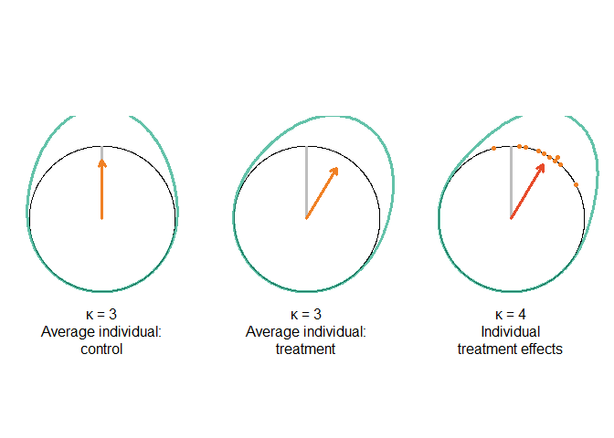

```r
par(pty = 's')
par(mar = c(0,0,0,0))
par(mfrow = c(1,3))
#Average individual for the control
DescriptCplot(k = kappa_treat_mean,
              ndata = ndata,
              refline = 0,
              pcol = NA,
              mvcol = col_rho
)
mtext('Average individual:\ncontrol',
      side = 1,
      line = 2)
#Average individual for the treatment
DescriptCplot(k = kappa_treat_mean,
              m = as.numeric(30),
              ndata = ndata,
              refline = 0,
              pcol = NA,
              mvcol = col_rho
)
mtext('Average individual:\ntreatment',
      side = 1,
      line = 2)
#Population individual turn biases
DescriptCplot(m = as.numeric(delta_mu),
              k = kappa_mu_treat,
              ndata = ndata,
              refline = 0,
              pcol = NA,
              mvcol = col_sd
)
points.circular(dt_delta,
                bins = 360/5-1,
                stack = TRUE,
                sep = 0.05,
                shrink = 1.25,
                col = col_rho
)
mtext('Individual\ntreatment effects',
      side = 1,
      line = 2)
```

# Fit a circular model

## Set up circular modelling functions

In order to fit a circular model using the shifted modulo and softplus links, we need to define a custom family. This family requires a custom log probability density function (LPDF), which in this case is just the von~Mises LPDF, but applied after estimates have been shifted from $[-\infty,\infty]$ to $[-\pi, \pi]$—where von~Mises LPDF $\>0$ in `Stan`.

```r
#set up required Stan functions
#shifted modulo in Stan code
mod_circular_fun = stanvar(scode = "
  real mod_circular(real y) {
    return fmod(y + pi(), 2*pi()) - pi();
  }
",
                           block = 'functions')

#custom likelihood function using the shifted modulo link
stan_unwrap_fun = stanvar(scode = "
  real unwrap_von_mises_lpdf(real y, real mu, real kappa) {
    return von_mises_lpdf(y | mod_circular(mu), kappa);
  }
  real unwrap_von_mises_vect_lpdf(vector y, real mu, real kappa) {
    real tmp = 0;
    for(i in 1:size(y))
    {
    tmp = tmp + unwrap_von_mises_lpdf(y[i] | mu, kappa);
    }
      return tmp;
  }
  real unwrap_von_mises_rng(real mu, real kappa) {
    return von_mises_rng( mod_circular(mu) , kappa);
  }
",
                          block = 'functions')

#Individual headings hyperparameter
stan_kappamu = stanvar(scode = "
real kappamu;
                           ",
                           block = "parameters") +
  stanvar(scode = "
real kappa_mu = log1p_exp(kappamu);
          ",
          block = 'genquant')

#Individual turns hyperparameter
stan_kappamudelta = stanvar(scode = "
real deltakappamu;
                           ",
                       block = "parameters") +
  stanvar(scode = "
real kappa_mu_delta = log1p_exp(kappamu + deltakappamu);
          ",
          block = 'genquant')

stan_all = mod_circular_fun + stan_unwrap_fun +
            stan_kappamu + stan_kappamudelta

#define the custom family
unwrap_von_mises = custom_family(
  name = "unwrap_von_mises",
  dpars = c("mu",
            "kappa"),
  links = c('identity',#N.B. the link function is defined via the LPD function
            "softplus"),
  lb = c(-pi,#lower bound of mu should be -pi
         0),
  ub = c(pi,#upper bound of mu should be pi
         NA),
  type = "real"#takes continuous response data
)
```

## Set up the model formula and priors

We can fit models to test three different hypotheses: an effect of treatment on population (and individual) mean angle and consistency (`form_treat`), an effect of treatment on consistency only (`form_kappa`), or no effect of treatment on either (`form_null`) while still accounting for individual differences. With `BRMS` these can be fitted as non-linear models, in which $\mu$ is the sum of the population level mean angle (`pmu`) and individual mean angles (`imu`).

Each parameter needs a carefullly-chosen prior. Here the prior on the concentration of individual biases $\kappa_\mu$ is set to expect partial pooling: by default individuals should be similar ($50\%$ probability density in $[10, 22]$), but with some probability that individual headings are weakly correlated ($\kappa_\mu \approx 1.0$) or uncorrelated ($\kappa_\mu \approx 0.0$).

```r
form_treat = bf(y ~ mu, #observed angle is predicted by mean angle
             nlf(mu ~ pmu + imu), #mean angle is predicted by the sum of population and individual means
             pmu ~ 1 + treatment,
             imu ~ 0 + ID + treatment + treatment:ID,
             kappa ~ 1 + treatment + (1 + treatment|ID),
             nl = TRUE)
#model without effect of treatment on mu
form_kappa = bf(y ~ mu, #observed angle is predicted by mean angle
             nlf(mu ~ pmu + imu), #mean angle is predicted by the sum of population and individual means
             pmu ~ 1 ,
             imu ~ 0 + ID ,
             kappa ~ 1 + treatment + (1 + treatment|ID),
             nl = TRUE)
#null model without effect of treatment
form_null = bf(y ~ mu, #observed angle is predicted by mean angle
             nlf(mu ~ pmu + imu), #mean angle is predicted by the sum of population and individual means
             pmu ~ 1 ,
             imu ~ 0 + ID ,
             kappa ~ 1  + (1 |ID),
             nl = TRUE)

#priors chosen for parameter recovery
prior_treat = prior('normal(0, 2*pi())',class = 'b', nlpar = 'pmu') + #wider prior helps avoid bias
  prior('unwrap_von_mises(0, 0.3)',class = 'b', nlpar = 'pmu', coef = 'treatment') + #expectation of moderate sized turns
  set_prior(paste("target +=",
                  'unwrap_von_mises_vect_lpdf(b_imu[1:N_1] | 0, log1p_exp(kappamu))',
                     '+ normal_lpdf(b_imu[1:N_1] | 0, 2*pi())'# additional prior to keep estimates from walking around the circle
                     ),
            check = FALSE) +
  set_prior(paste("target +=",
                  'unwrap_von_mises_vect_lpdf(b_imu[(N_1 + 1) : (M_1 * N_1)] | 0, log1p_exp(kappamu+deltakappamu))',
                     '+ normal_lpdf(b_imu[(N_1 + 1) : (M_1 * N_1)] | 0, 2*pi())'# additional prior to keep estimates from walking around the circle
                     ),
            check = FALSE) +
  # set_prior("target += normal_lpdf(kappamu | 3.0, 3.0)", #prior to higher values, indiv differences should be small
  set_prior("target += lognormal_lpdf(log1p_exp(kappamu) | log(15), 0.6)", #shrinkage prior,
            check = FALSE) +
  # set_prior("target += normal_lpdf(deltakappamu | 0.0, 1.0)", #turns should follow individual distribution
  #           check = FALSE) +
  set_prior("target += lognormal_lpdf(log1p_exp(kappamu + deltakappamu) | log(15), 0.6)", #prior to higher values, indiv differences should be small
            check = FALSE) +
  prior('normal( 3.0, 3.0)', class = 'Intercept', dpar = 'kappa') + #shouldn't be too tight, want to estimate
  prior('normal( 0.0, 3.0)', class = 'b', dpar = 'kappa', coef = 'treatment') + #turns should not affect population accuracy
  prior('student_t(3, 0, 3.0)', class = 'sd', dpar = 'kappa') +  #now expect substantial variation, but too much makes sampling unstable
  prior('student_t(3, 0, 1.0)', class = 'sd', dpar = 'kappa', coef = 'treatment', group = 'ID') #now expect substantial variation, but too much makes sampling unstable

#priors chosen for parameter recovery
prior_kappa = prior('normal(0, 2*pi())',class = 'b', nlpar = 'pmu') + #wider prior helps avoid bias
  set_prior(paste("target +=",
                  'unwrap_von_mises_vect_lpdf(b_imu[1:N_1] | 0, log1p_exp(kappamu))',
                     '+ normal_lpdf(b_imu[1:N_1] | 0, 2*pi())'# additional prior to keep estimates from walking around the circle
                     ),
            check = FALSE) +
  set_prior("target += lognormal_lpdf(log1p_exp(kappamu) | log(15), 0.6)", #shrinkage prior,
            check = FALSE) +
  # set_prior("target += normal_lpdf(deltakappamu | 0.0, 1.0)", #turns should follow individual distribution
  #           check = FALSE) +
  set_prior("target += lognormal_lpdf(log1p_exp(kappamu + deltakappamu) | log(30), 0.6)", #prior to higher values, indiv differences should be small
            check = FALSE) +
  prior('normal( 3.0, 3.0)', class = 'Intercept', dpar = 'kappa') + #shouldn't be too tight, want to estimate
  prior('normal( 0.0, 3.0)', class = 'b', dpar = 'kappa', coef = 'treatment') + #turns should not affect population accuracy
  prior('student_t(3, 0, 3.0)', class = 'sd', dpar = 'kappa') +  #now expect substantial variation, but too much makes sampling unstable
  prior('student_t(3, 0, 1.0)', class = 'sd', dpar = 'kappa', coef = 'treatment', group = 'ID') #now expect substantial variation, but too much makes sampling unstable

#priors for null model
prior_null = prior('normal(0, 2*pi())',class = 'b', nlpar = 'pmu') + #wider prior helps avoid bias
  set_prior(paste("target +=",
                  'unwrap_von_mises_vect_lpdf(b_imu[1:N_1] | 0, log1p_exp(kappamu))',
                     '+ normal_lpdf(b_imu[1:N_1] | 0, 2*pi())'# additional prior to keep estimates from walking around the circle
                     ),
            check = FALSE) +
  # set_prior("target += normal_lpdf(kappamu | 3.0, 3.0)", #prior to higher values, indiv differences should be small
  set_prior("target += lognormal_lpdf(log1p_exp(kappamu) | log(15), 0.6)", #shrinkage prior,
            check = FALSE) +
  # set_prior("target += normal_lpdf(deltakappamu | 0.0, 1.0)", #turns should follow individual distribution
  #           check = FALSE) +
  set_prior("target += lognormal_lpdf(log1p_exp(kappamu + deltakappamu) | log(15), 0.6)", #prior to higher values, indiv differences should be small
            check = FALSE) +
  prior('normal( 3.0, 3.0)', class = 'Intercept', dpar = 'kappa') + #shouldn't be too tight, want to estimate
  prior('student_t(3, 0, 3.0)', class = 'sd', dpar = 'kappa') #now expect substantial variation, but too much makes sampling unstable
```

## Fit the model

```r
glmm_treatment = brm(
  formula = form_treat,
  data = treat_data,
  family = unwrap_von_mises,
  stanvars = stan_all,
  prior = prior_treat,
  cores = 4,
  silent = 1, # without printing
  refresh = 1000, # echo chain progress every n iterations
  backend = 'cmdstan',
  save_pars = save_pars(all = TRUE),
  control = list(adapt_delta = 0.97)#slower, but more robust sampling
)
```

```
## Running MCMC with 4 parallel chains...
##
## Chain 1 Iteration:    1 / 2000 [  0%]  (Warmup)
## Chain 2 Iteration:    1 / 2000 [  0%]  (Warmup)
## Chain 3 Iteration:    1 / 2000 [  0%]  (Warmup)
## Chain 4 Iteration:    1 / 2000 [  0%]  (Warmup)
## Chain 2 Iteration: 1000 / 2000 [ 50%]  (Warmup)
## Chain 2 Iteration: 1001 / 2000 [ 50%]  (Sampling)
## Chain 1 Iteration: 1000 / 2000 [ 50%]  (Warmup)
## Chain 1 Iteration: 1001 / 2000 [ 50%]  (Sampling)
## Chain 4 Iteration: 1000 / 2000 [ 50%]  (Warmup)
## Chain 4 Iteration: 1001 / 2000 [ 50%]  (Sampling)
## Chain 3 Iteration: 1000 / 2000 [ 50%]  (Warmup)
## Chain 3 Iteration: 1001 / 2000 [ 50%]  (Sampling)
## Chain 2 Iteration: 2000 / 2000 [100%]  (Sampling)
## Chain 2 finished in 114.6 seconds.
## Chain 1 Iteration: 2000 / 2000 [100%]  (Sampling)
## Chain 1 finished in 123.7 seconds.
## Chain 4 Iteration: 2000 / 2000 [100%]  (Sampling)
## Chain 4 finished in 137.2 seconds.
## Chain 3 Iteration: 2000 / 2000 [100%]  (Sampling)
## Chain 3 finished in 180.2 seconds.
##
## All 4 chains finished successfully.
## Mean chain execution time: 138.9 seconds.
## Total execution time: 180.4 seconds.
```

```r
glmm_kappa = brm(
  formula = form_kappa,
  data = treat_data,
  family = unwrap_von_mises,
  stanvars = stan_all,
  prior = prior_kappa,
  cores = 4,
  silent = 1, # without printing
  refresh = 1000, # echo chain progress every n iterations
  save_pars = save_pars(all = TRUE),
  backend = 'cmdstan',
  control = list(adapt_delta = 0.97)#slower, but more robust sampling
)
```

```
## Running MCMC with 4 parallel chains...
##
## Chain 1 Iteration:    1 / 2000 [  0%]  (Warmup)
## Chain 2 Iteration:    1 / 2000 [  0%]  (Warmup)
## Chain 3 Iteration:    1 / 2000 [  0%]  (Warmup)
## Chain 4 Iteration:    1 / 2000 [  0%]  (Warmup)
## Chain 2 Iteration: 1000 / 2000 [ 50%]  (Warmup)
## Chain 2 Iteration: 1001 / 2000 [ 50%]  (Sampling)
## Chain 3 Iteration: 1000 / 2000 [ 50%]  (Warmup)
## Chain 3 Iteration: 1001 / 2000 [ 50%]  (Sampling)
## Chain 4 Iteration: 1000 / 2000 [ 50%]  (Warmup)
## Chain 4 Iteration: 1001 / 2000 [ 50%]  (Sampling)
## Chain 1 Iteration: 1000 / 2000 [ 50%]  (Warmup)
## Chain 1 Iteration: 1001 / 2000 [ 50%]  (Sampling)
## Chain 4 Iteration: 2000 / 2000 [100%]  (Sampling)
## Chain 4 finished in 51.2 seconds.
## Chain 3 Iteration: 2000 / 2000 [100%]  (Sampling)
## Chain 3 finished in 57.3 seconds.
## Chain 2 Iteration: 2000 / 2000 [100%]  (Sampling)
## Chain 2 finished in 59.7 seconds.
## Chain 1 Iteration: 2000 / 2000 [100%]  (Sampling)
## Chain 1 finished in 62.4 seconds.
##
## All 4 chains finished successfully.
## Mean chain execution time: 57.6 seconds.
## Total execution time: 62.4 seconds.
```

```r
glmm_null = brm(
  formula = form_null,
  data = treat_data,
  family = unwrap_von_mises,
  stanvars = stan_all,
  prior = prior_null,
  cores = 4,
  silent = 1, # without printing
  refresh = 1000, # echo chain progress every n iterations
  save_pars = save_pars(all = TRUE),
  backend = 'cmdstan',
  control = list(adapt_delta = 0.97)#slower, but more robust sampling
)
```

```
## Running MCMC with 4 parallel chains...
##
## Chain 1 Iteration:    1 / 2000 [  0%]  (Warmup)
## Chain 2 Iteration:    1 / 2000 [  0%]  (Warmup)
## Chain 3 Iteration:    1 / 2000 [  0%]  (Warmup)
## Chain 4 Iteration:    1 / 2000 [  0%]  (Warmup)
## Chain 2 Iteration: 1000 / 2000 [ 50%]  (Warmup)
## Chain 2 Iteration: 1001 / 2000 [ 50%]  (Sampling)
## Chain 4 Iteration: 1000 / 2000 [ 50%]  (Warmup)
## Chain 4 Iteration: 1001 / 2000 [ 50%]  (Sampling)
## Chain 3 Iteration: 1000 / 2000 [ 50%]  (Warmup)
## Chain 3 Iteration: 1001 / 2000 [ 50%]  (Sampling)
## Chain 1 Iteration: 1000 / 2000 [ 50%]  (Warmup)
## Chain 1 Iteration: 1001 / 2000 [ 50%]  (Sampling)
## Chain 2 Iteration: 2000 / 2000 [100%]  (Sampling)
## Chain 2 finished in 34.2 seconds.
## Chain 4 Iteration: 2000 / 2000 [100%]  (Sampling)
## Chain 4 finished in 36.2 seconds.
## Chain 3 Iteration: 2000 / 2000 [100%]  (Sampling)
## Chain 3 finished in 36.3 seconds.
## Chain 1 Iteration: 2000 / 2000 [100%]  (Sampling)
## Chain 1 finished in 42.2 seconds.
##
## All 4 chains finished successfully.
## Mean chain execution time: 37.2 seconds.
## Total execution time: 42.3 seconds.
```

We can now inspect the convergence heuristics of each model, which are a prerequisite for comparing them. Since circular estimates are periodic and unbounded, chains may have estimates separated by multiples of $2\pi$, which triggers warnings. These estimates need to be transformed before convergence can be assesses. We will first focus on the linear parameters.

```r
#extract the medians of all linear parameters
sm_treat = summary(glmm_treatment, robust = TRUE)
```

```
## Warning: Parts of the model have not converged (some Rhats are > 1.05). Be
## careful when analysing the results! We recommend running more iterations and/or
## setting stronger priors.
```

```r
sm_kappa = summary(glmm_kappa, robust = TRUE)
```

```
## Warning: Parts of the model have not converged (some Rhats are > 1.05). Be
## careful when analysing the results! We recommend running more iterations and/or
## setting stronger priors.
```

```r
sm_null = summary(glmm_null, robust = TRUE)
#treatment model
print(sm_treat$fixed[c('kappa_Intercept',
                      'kappa_treatment'
                     ),],
      digits = 3)
```

```
##                 Estimate Est.Error l-95% CI u-95% CI Rhat Bulk_ESS Tail_ESS
## kappa_Intercept    3.152     0.477    2.205     4.22    1     2148     2428
## kappa_treatment    0.278     0.448   -0.613     1.22    1     4514     2784
```

```r
print(sm_treat$spec_pars,
      digits = 3)
```

```
##                Estimate Est.Error l-95% CI u-95% CI Rhat Bulk_ESS Tail_ESS
## kappa_mu           4.63     1.465     2.45     8.46    1     2575     2304
## kappa_mu_delta     2.85     0.829     1.51     4.85    1     3973     3117
```

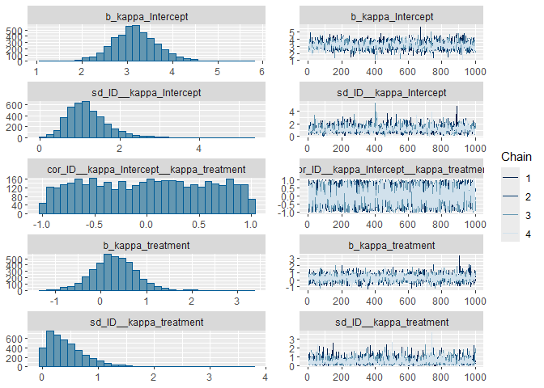

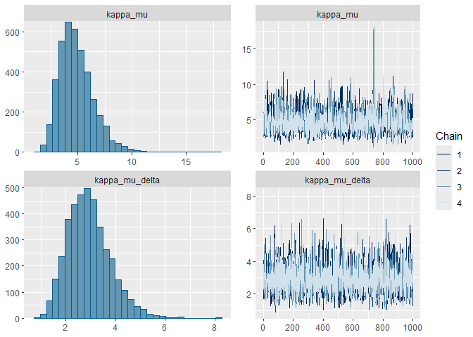

```r
plot(glmm_treatment,
     variable = c('kappa_Intercept',
                  'kappa_treatment',
                  'kappa_mu',
                  'kappa_mu_delta'
                  ),
     regex = TRUE,
     ask = FALSE)
```

```r
#kappa model
print(sm_kappa$fixed[c('kappa_Intercept',
                      'kappa_treatment'
                     ),],
      digits = 3)
```

```
##                 Estimate Est.Error l-95% CI u-95% CI Rhat Bulk_ESS Tail_ESS
## kappa_Intercept    2.080     0.681     0.71     3.54 1.08     33.6      206
## kappa_treatment    0.453     1.192    -1.98     2.67 1.08     33.9     1264
```

```r
print(sm_kappa$spec_pars,
      digits = 3)
```

```
##                Estimate Est.Error l-95% CI u-95% CI Rhat Bulk_ESS Tail_ESS
## kappa_mu           7.96      3.11     3.76     19.8 1.06     40.4      134
## kappa_mu_delta    30.61     17.52     9.44     94.4 1.00   1949.5      936
```

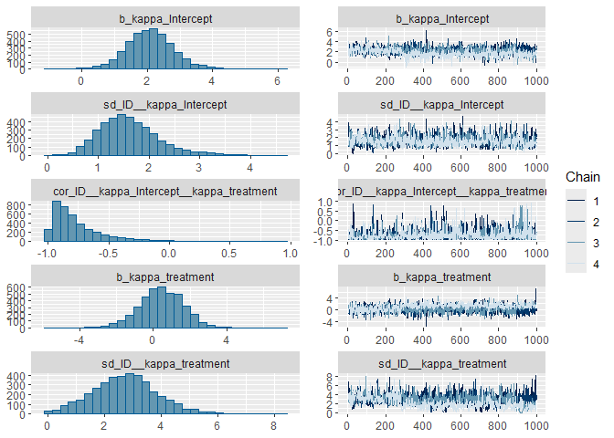

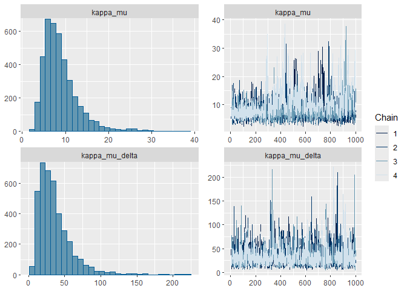

```r
plot(glmm_kappa,
     variable = c('kappa_Intercept',
                  'kappa_treatment',
                  'kappa_mu'
                  ),
     regex = TRUE,
     ask = FALSE)
```

```r
#null model
print(sm_null$fixed[c('kappa_Intercept'
                     ),],
      digits = 3)
```

```
##                 Estimate Est.Error l-95% CI u-95% CI Rhat Bulk_ESS Tail_ESS
## kappa_Intercept     2.09     0.299     1.48     2.84    1     1361     1647
```

```r
print(sm_null$spec_pars,
      digits = 3)
```

```
##                Estimate Est.Error l-95% CI u-95% CI Rhat Bulk_ESS Tail_ESS
## kappa_mu           13.1      5.35     5.70     29.3    1     2031     1716
## kappa_mu_delta     14.9      8.52     4.51     51.0    1     2315     1434
```

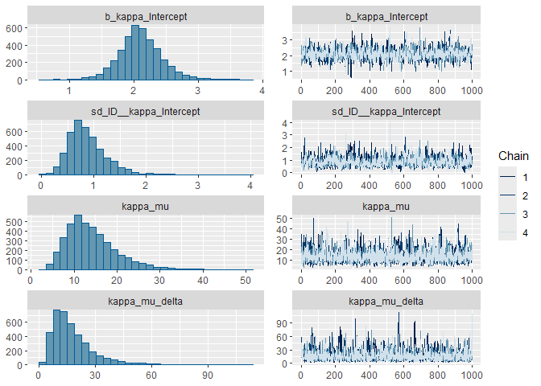

```r
plot(glmm_null,
     variable = c('kappa_Intercept',
                  'kappa_treatment',
                  'kappa_mu',
                  'kappa_mu_delta'
                  ),
     regex = TRUE,
     ask = FALSE)
```

```r
#treatment model
#population mean angle
UnwrapRhats(glmm_treatment, variable = 'pmu')
```

```
## b_pmu_Intercept b_pmu_treatment
##         1.00003         1.00177
```

```r
#individual mean angles
UnwrapRhats(glmm_treatment, variable = 'imu')
```

```
##            b_imu_ID1            b_imu_ID2            b_imu_ID3
##              0.99988              1.00034              0.99997
##            b_imu_ID4            b_imu_ID5            b_imu_ID6
##              1.00005              1.00014              0.99995
##            b_imu_ID7            b_imu_ID8            b_imu_ID9
##              1.00007              1.00029              0.99993
##           b_imu_ID10      b_imu_treatment  b_imu_ID2:treatment
##              0.99999              1.00120              1.00031
##  b_imu_ID3:treatment  b_imu_ID4:treatment  b_imu_ID5:treatment
##              1.00015              0.99979              1.00094
##  b_imu_ID6:treatment  b_imu_ID7:treatment  b_imu_ID8:treatment
##              1.00130              0.99987              1.00021
##  b_imu_ID9:treatment b_imu_ID10:treatment
##              1.00116              1.00000
```

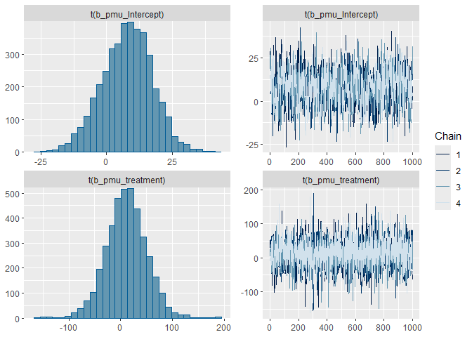

```r
plot(glmm_treatment,
     variable = 'pmu',
     transform = unwrap_circular_deg,
     regex = TRUE,
     ask = FALSE)
```

```r
#kappa model
#population mean angle
UnwrapRhats(glmm_kappa, variable = 'pmu')
```

```
## b_pmu_Intercept
##         1.05715
```

```r
#individual mean angles
UnwrapRhats(glmm_kappa, variable = 'imu')
```

```
##  b_imu_ID1  b_imu_ID2  b_imu_ID3  b_imu_ID4  b_imu_ID5  b_imu_ID6  b_imu_ID7
##    1.04469    1.02528    1.00777    1.03945    1.03369    1.10695    1.00098
##  b_imu_ID8  b_imu_ID9 b_imu_ID10
##    1.03506    1.01010    1.02673
```

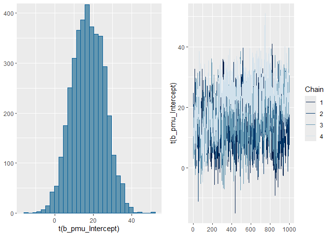

```r
plot(glmm_kappa,
     variable = 'pmu',
     transform = unwrap_circular_deg,
     regex = TRUE,
     ask = FALSE)
```

```r
#null model
#population mean angle
UnwrapRhats(glmm_null, variable = 'pmu')
```

```
## b_pmu_Intercept
##         1.00048
```

```r
#individual mean angles
UnwrapRhats(glmm_null, variable = 'imu')
```

```
##  b_imu_ID1  b_imu_ID2  b_imu_ID3  b_imu_ID4  b_imu_ID5  b_imu_ID6  b_imu_ID7
##    1.00022    1.00185    1.00004    1.00008    0.99990    1.00127    1.00020
##  b_imu_ID8  b_imu_ID9 b_imu_ID10
##    1.00082    1.00003    0.99997
```

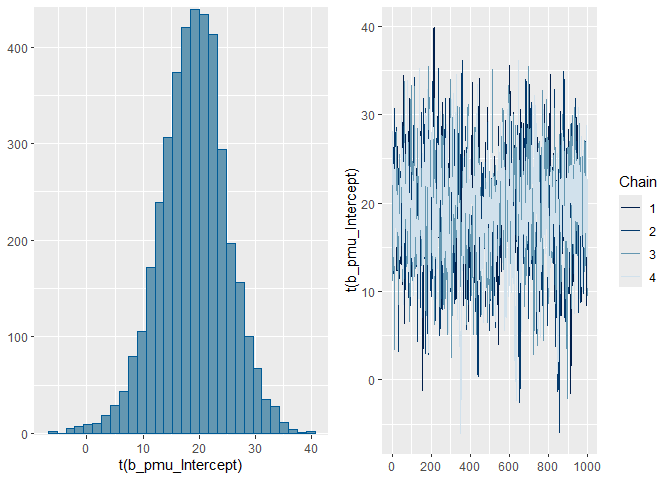

```r
plot(glmm_null,
     variable = 'pmu',
     transform = unwrap_circular_deg,
     regex = TRUE,
     ask = FALSE)
```

# Test hypothesis of treatment effect

To compare the predictive power of the models, we can use leave-one-out cross-validation (LOO-CV) to calculate the estimated log predictive density (ELPD) and its standard error for each model. A good model increases ELPD.

```r
#better predictions should justify fitting a treatment model
loo_null = loo(glmm_null, moment_match = TRUE)
```

```
## Recompiling the model with 'rstan'
```

[output not shown]

```
## Recompilation done
```

```r
loo_kappa = loo(glmm_kappa, moment_match = TRUE)
```

```
## Recompiling the model with 'rstan'
```

[output not shown]

```
## Recompilation done
```

```r
loo_treat = loo(glmm_treatment, moment_match = TRUE)
```

```
## Recompiling the model with 'rstan'
```

[output not shown]

```
## Recompilation done
```

```r
lc_nulltreat = loo_compare(loo_null, loo_kappa, loo_treat)
print(lc_nulltreat)
```

```
##                elpd_diff se_diff
## glmm_treatment   0.0       0.0
## glmm_kappa     -93.4       9.8
## glmm_null      -95.1      11.6
```

We can plot this model comparison to get an impression of the scale of the difference in plausibility between the hypotheses.

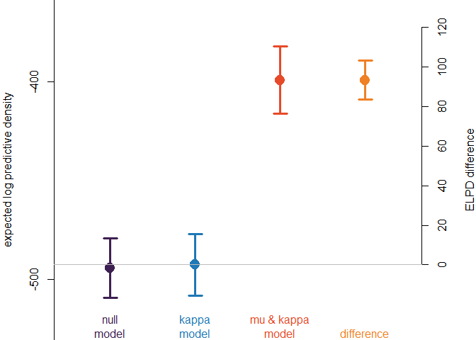

```r
lc_plot = data.frame(elpd = c(loo_null$estimates['elpd_loo','Estimate'],
                              loo_kappa$estimates['elpd_loo','Estimate'],
                              loo_treat$estimates['elpd_loo','Estimate'],
                              loo_kappa$estimates['elpd_loo','Estimate'] - lc_nulltreat[2,'elpd_diff']),
                     se = c(loo_null$estimates['elpd_loo','SE'],
                            loo_kappa$estimates['elpd_loo','SE'],
                            loo_treat$estimates['elpd_loo','SE'],
                            lc_nulltreat[2,'se_diff'])
                     )

par(mar = c(0,4,0,4),
    mfrow = c(1,1))
plot(x = 1:dim(lc_plot)[1],
     y = lc_plot$elpd,
     xlab = '',
     ylab = 'expected log predictive density',
     xlim = c(1,dim(lc_plot)[1]) + c(-1,1)*0.5,
     ylim = with(lc_plot, {range(elpd+se%*% t(c(-2,2)))}), #within 2sigma of all estimates
     pch = 19,
     col = c(col_obs, col_kappa, col_sd, col_rho),
     cex = 2,
     axes = FALSE)
with(lc_plot,
     {
arrows(x0 = 1:dim(lc_plot)[1],
       x1 = 1:dim(lc_plot)[1],
       y0 = elpd - se,
       y1 = elpd + se,
       code = 3,
       angle = 90,
       length = 0.1,
       lwd = 3,
       col =  c(col_obs, col_kappa, col_sd, col_rho)
       )
     }
)
axis(2,
     at = pretty(c(0,
                   with(lc_plot, {range(elpd+se%*% t(c(-2,2)))}))
                 )
     )
axis(4,
     at = with(lc_plot,
               {
               seq(from = elpd[2], to = elpd[dim(lc_plot)[1]] + se[dim(lc_plot)[1]]*4, by = 20)
               }
               ),
     labels = with(lc_plot,
                          {
                            seq(from = 0, to =  elpd[dim(lc_plot)[1]] + se[dim(lc_plot)[1]]*4 - elpd[2],  by = 20)
                          }
     )
)
abline(h = lc_plot$elpd[2],
       col = 'gray')
mtext(text = 'ELPD difference',
      side = 4,
      line = 3
      )
mtext(side = 1,
      line = -1,
      at = 1:dim(lc_plot)[1],
     text = c('null\nmodel',
              'kappa\nmodel',
              'mu & kappa\nmodel',
              'difference'),
     col = c(col_obs, col_kappa, col_sd, col_rho)
     )
```

# Plot model predictions

We can also extract the model predictions. Since we simulated the data, we can compare the model estimates (red and yellow shaded regions) with the true parameters.

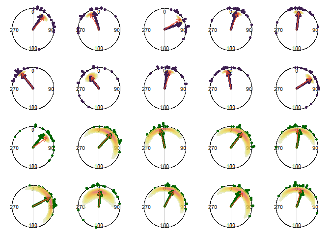

```r
draws_treat = as_draws_df(glmm_treatment)

par(pty = 's')
par(mar = c(0,0,0,0),
    mfrow = c(2*2,ceiling(nindiv/2)))
#control
for(i in 1:length(dt_treat) )
{
  mu_name = paste0('b_imu_ID',i)
  kappa_name = paste0('r_ID__kappa[',i,',Intercept]')
  PCfun(dt_id_treat[[i]],
        col = col_obs,
        sep = 0.05,
        shrink = 1.25,
        plot_rho = FALSE)
  Draws2Cont(draws_treat,
             x_string = 'sin(b_pmu_Intercept + get(mu_name))*
                         A1(softplus(Intercept_kappa+get(kappa_name)))',
             y_string = 'cos(b_pmu_Intercept + get(mu_name))*
                         A1(softplus(Intercept_kappa+get(kappa_name)))',
             ngrid = 100, # needs higher resolution to avoid spillover
             cropc = TRUE
  )
  arrows.circular(x = dt_treat[i],
                  y = A1(kappa_id_treat[i]),
                  col = col_obs,
                  lwd = 5,
                  length = 0.1/1.25
  )
  with(draws_treat,
       arrows.circular(x = median.circular(
         circular(x =
                    mod_circular(b_pmu_Intercept + get(mu_name)),
                  units = 'radians',
                  rotation = 'clock',
                  zero = pi/2)
       )[1],
       y = A1(softplus(median(Intercept_kappa+get(kappa_name)))),
       lwd = 2,
       length = 0.1/1.25,
       col = adjustcolor(col_sd, alpha.f = 200/255))
  )
}
#treatment
for(i in 1:length(dt_delta) )
{
  mu_name = paste0('b_imu_ID',i)
  mu_delta_name = if(i>1)
                  {paste0('b_imu_ID',i , ':treatment')}else
                  {paste0('b_imu_', 'treatment')}
  kappa_name = paste0('r_ID__kappa[',i,',Intercept]')
  kappa_delta_name = paste0('r_ID__kappa[',i,',treatment]')
  PCfun(dt_id_delta[[i]],
        col = 'darkgreen',
        sep = 0.05,
        shrink = 1.25,
        plot_rho = FALSE)
  Draws2Cont(draws_treat,
             x_string = 'sin(b_pmu_Intercept + b_pmu_treatment + get(mu_name) + get(mu_delta_name))*
                         A1(softplus(Intercept_kappa+b_kappa_treatment+get(kappa_name)+get(kappa_delta_name)))',
             y_string = 'cos(b_pmu_Intercept + b_pmu_treatment + get(mu_name) + get(mu_delta_name))*
                         A1(softplus(Intercept_kappa+b_kappa_treatment+get(kappa_name)+get(kappa_delta_name)))',
             ngrid = 100, # needs higher resolution to avoid spillover
             cropc = TRUE
            )
  arrows.circular(x = dt_delta[i],
                  y = A1(kappa_id_treat[i]),
                  col = 'darkgreen',
                  lwd = 5,
                  length = 0.1/1.25
  )
  with(draws_treat,
       arrows.circular(x = median.circular(
         circular(x =
                    mod_circular(b_pmu_Intercept+ b_pmu_treatment + get(mu_name)  + get(mu_delta_name)),
                  units = 'radians',
                  rotation = 'clock',
                  zero = pi/2)
       )[1],
       y = A1(softplus(median(Intercept_kappa + b_kappa_treatment + get(kappa_name) + get(kappa_delta_name)))),
       lwd = 2,
       length = 0.1/1.25,
       col = adjustcolor(col_sd, alpha.f = 200/255))
  )
}
```

We can also compare the model parameters with the population parameters. Here we see that the estimates of the population mean angle favour a right turn, but there is a lot of uncertainty about the exact size of the turn, or even whether it was to the right or the left. This is influenced by the wide spread of individual mean angles and turn angles, which the model recovered well.

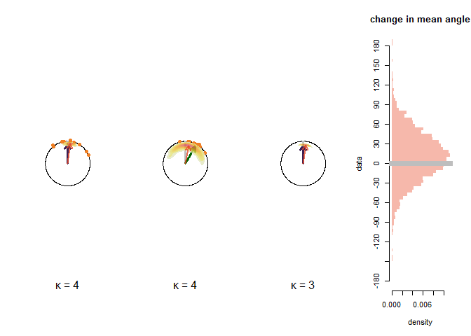

```r
par(mfrow = c(1,4))
#Add the population of biases
DescriptCplot(k = kappa_mu_treat,
              ndata = nindiv,
              refline = 0,
              denscol = NA,
              pcol = NA,
              mvcol = col_obs
)
points.circular(dt_treat,
                bins = 360/5-1,
                stack = TRUE,
                sep = 0.05,
                shrink = 1.25,
                col = col_rho
)

Draws2Cont(draws = draws_treat,
           x_string = 'sin(b_pmu_Intercept)*
             A1(kappa_mu)',
           y_string = 'cos(b_pmu_Intercept)*
             A1(kappa_mu)',
           ngrid = 100, # needs higher resolution to avoid spillover
           cropc = TRUE
)

with(draws_treat,
     arrows.circular(x = mean.circular(circular(b_pmu_Intercept,
                                                units = 'radians',
                                                rotation = 'clock',
                                                zero = pi/2)
     )[1],
     y = A1(median(kappa_mu)),
     lwd = 2,
     length = 0.1/1.25,
     col = adjustcolor(col_sd, alpha.f = 200/255))
)

#Add the population of turns
DescriptCplot(m = delta_mu,
              k = kappa_mu_treat,
              ndata = nindiv,
              refline = 0,
              denscol = NA,
              pcol = NA,
              mvcol = 'darkgreen'
)
points.circular(dt_delta,
                bins = 360/5-1,
                stack = TRUE,
                sep = 0.05,
                shrink = 1.25,
                col = col_rho
)

Draws2Cont(draws = draws_treat,
           x_string = 'sin(b_pmu_treatment)*
             A1(kappa_mu_delta)',
           y_string = 'cos(b_pmu_treatment)*
             A1(kappa_mu_delta)',
           ngrid = 100, # needs higher resolution to avoid spillover
           cropc = TRUE
)
with(draws_treat,
     arrows.circular(x = mean.circular(circular(b_pmu_treatment,
                                                units = 'radians',
                                                rotation = 'clock',
                                                zero = pi/2)
     )[1],
     y = A1(median(kappa_mu_delta)),
     lwd = 2,
     length = 0.1/1.25,
     col = adjustcolor(col_sd, alpha.f = 200/255))
)

#Add description of the average individual
DescriptCplot(k = kappa_treat_mean,
              ndata = ndata/2,
              refline = 0,
              denscol = NA,
              pcol = NA,
              mvcol = col_obs
)
Draws2Cont(draws = draws_treat,
           x_string = 'sin(b_pmu_Intercept)*
             A1(softplus(Intercept_kappa))',
           y_string = 'cos(b_pmu_Intercept)*
             A1(softplus(Intercept_kappa))',
           ngrid = 100, # needs higher resolution to avoid spillover
           cropc = TRUE
)
with(draws_treat,
     arrows.circular(x = mean.circular(circular(b_pmu_Intercept,
                                                units = 'radians',
                                                rotation = 'clock',
                                                zero = pi/2)
     )[1],
     y = A1(softplus(median(Intercept_kappa))),
     lwd = 2,
     length = 0.1/1.25,
     col = adjustcolor(col_sd, alpha.f = 200/255))
)



with(draws_treat,
     VertHist(data = unwrap_circular_deg(b_pmu_treatment),
              main = 'change in mean angle',
              ylim = c(-180, 180),
              col = adjustcolor(col_sd, alpha.f = 100/255),
              cex.axis = 0.7,
              axes = FALSE))
axis(side = 1)
axis(side = 2,
     at = -6:6*(180/6) )
abline(h = 0,
       col = 'gray',
       lwd = 7)
```

```r
#estimate somewhat favours a turn
with(draws_treat,
     paste0(mean(b_pmu_treatment > 0)*100, '%')
)
```

```
## [1] "71.65%"
```